# Presentation

Anna Jenkins

Last Edited Tuesday, December 07, 2021 @ 01:52 PM

## Setup

### Packages Used

```r
library(dplyr)
library(ggplot2)
library(readxl)
library(tidyverse)
library(knitr)
library(DT)
```

### Datasets Used

```r
Index <- read.csv("~/Git_repositories/STT2860project2/dataraw/billionaires_2021_10_31.csv", sep=",")
excel_sheets("~/Git_repositories/STT2860project2/dataraw/MITpresident19762020.xlsx")
```

```
[1] "1976-2020-president" "Source"
```

```r
president <- read_excel("~/Git_repositories/STT2860project2/dataraw/MITpresident19762020.xlsx", sheet = "1976-2020-president")
glimpse(president)
```

```
Rows: 4,287
Columns: 15
$ year             <dbl> 1976, 1976, 1976, 1976, 1976, 1976, 1976, 1976, 1976,…
$ state            <chr> "ALABAMA", "ALABAMA", "ALABAMA", "ALABAMA", "ALABAMA"…
$ state_po         <chr> "AL", "AL", "AL", "AL", "AL", "AL", "AL", "AK", "AK",…
$ state_fips       <dbl> 1, 1, 1, 1, 1, 1, 1, 2, 2, 2, 2, 4, 4, 4, 4, 4, 4, 4,…
$ state_cen        <dbl> 63, 63, 63, 63, 63, 63, 63, 94, 94, 94, 94, 86, 86, 8…
$ state_ic         <dbl> 41, 41, 41, 41, 41, 41, 41, 81, 81, 81, 81, 61, 61, 6…
$ office           <chr> "US PRESIDENT", "US PRESIDENT", "US PRESIDENT", "US P…
$ candidate        <chr> "CARTER, JIMMY", "FORD, GERALD", "MADDOX, LESTER", "B…
$ party_detailed   <chr> "DEMOCRAT", "REPUBLICAN", "AMERICAN INDEPENDENT PARTY…
$ writein          <lgl> FALSE, FALSE, FALSE, FALSE, FALSE, FALSE, TRUE, FALSE…
$ candidatevotes   <dbl> 659170, 504070, 9198, 6669, 1954, 1481, 308, 71555, 4…
$ totalvotes       <dbl> 1182850, 1182850, 1182850, 1182850, 1182850, 1182850,…
$ version          <dbl> 20210113, 20210113, 20210113, 20210113, 20210113, 202…
$ notes            <lgl> NA, NA, NA, NA, NA, NA, NA, NA, NA, NA, NA, NA, NA, N…
$ party_simplified <chr> "DEMOCRAT", "REPUBLICAN", "OTHER", "OTHER", "OTHER", …
```

# Billionaire’s Dataset

```r
head(Index)
```

```
  Rank             Name Total_Net_Worth Total_Net_Worth_Bil LastChange
1    1       Elon Musk            $311B                 311    +$9.32B
2    2      Jeff Bezos            $195B                 195    -$3.79B
3    3 Bernard Arnault            $167B                 167     -$544M
4    4      Bill Gates            $136B                 136     +$906M
5    5      Larry Page            $131B                 131    +$1.71B
6    6     Sergey Brin            $126B                 126    +$1.64B
  LastChange_Bil YTDChange YTDChange_Bil      Country   Industry
1          9.320    +$141B        141.00 UnitedStates Technology
2         -3.790   +$5.06B          5.06 UnitedStates Technology
3         -0.544   +$52.7B         52.70       France   Consumer
4          0.906   +$4.40B          4.40 UnitedStates Technology
5          1.710   +$48.7B         48.70 UnitedStates Technology
6          1.640   +$46.7B         46.70 UnitedStates Technology
```

```r
Index2 <- Index %>%
  group_by(Industry) %>%
  summarize(Change = sum(LastChange_Bil)) %>%
  arrange(desc(Change))
```

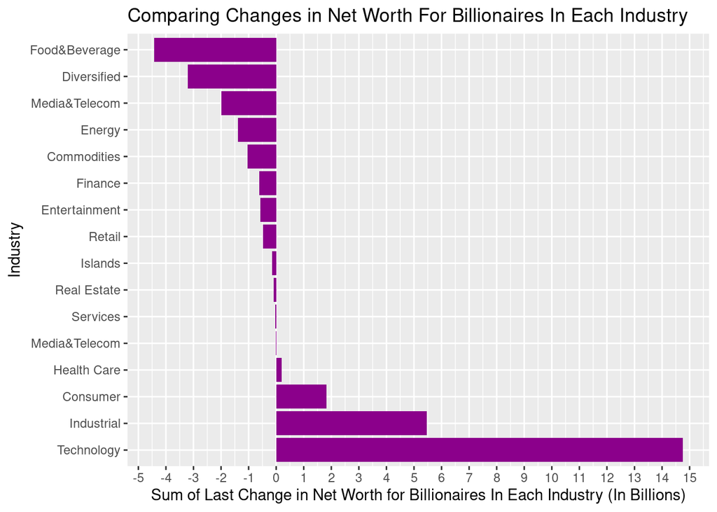

```r
ggplot(Index2, aes(Change, reorder(Industry, -Change))) +
  geom_col(fill = "darkmagenta") +
 scale_x_continuous(n.breaks = 20) +
  xlab("Sum of Last Change in Net Worth for Billionaires In Each Industry (In Billions)") +
  ylab("Industry") +
  labs(title = "Comparing Changes in Net Worth For Billionaires In Each Industry")
```

The plot that I chose shows the total sum of latest net worth change that has occurred for billionaires in each industry, in billions. This plot shows that the 500 richest people belong to a total of about 16 different industries, and the group of billionaires with the largest most recent gain in money overall were those that work in technology. There also were only about 3 industries that had a substantial increase in total net worth in this change, while 8 industries had a significant decrease in total net worth. This may show which industries are currenlty doing well, or may be an insigificant change due to a single period of change.